# *-Cat vs Dog Classifier-*

```python
import numpy as np
import matplotlib.pyplot as plt
%matplotlib notebook
import tensorflow as tf
from scipy import misc
import pandas as pd
import cv2
```

```python
import os
```

```python
"""train = []

for filename in os.listdir('C:/Users/Owner/Desktop/CAT DOG/train/train/train/'):
    if filename.endswith('.jpg'):
        img = misc.imread('C:/Users/Owner/Desktop/CAT DOG/train/train/train/{}'.format(filename))
        img = img[::2,::2]
        img = cv2.resize(img, (125,125))
        img = (img/225.0).reshape(-1)
        train.append(img)
        continue
    else:
        continue"""
```

```python
arr = os.listdir('C:/Users/Owner/Desktop/CAT DOG/train/train/train/')
np.random.shuffle(arr)
```

```python
X = []
Y = []

import re
for filename in arr:
    img = misc.imread('C:/Users/Owner/Desktop/CAT DOG/train/train/train/{}'.format(filename))
    img = img[::2,::2]
    img = cv2.resize(img, (125,125))
    img = (img/225.0).reshape(-1)
    X.append(img)
    if filename.startswith('cat'): Y.append(1)
    else: Y.append(0)
```

```python
np.save('input_data.npy', X)
```

```python
np.save('label.npy', Y)
```

#### Cat image after resizing to 125*125

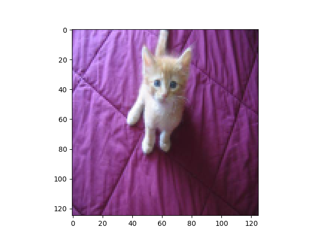

```python
plt.imshow(train[20])
```

#### Cat image with original dimensions

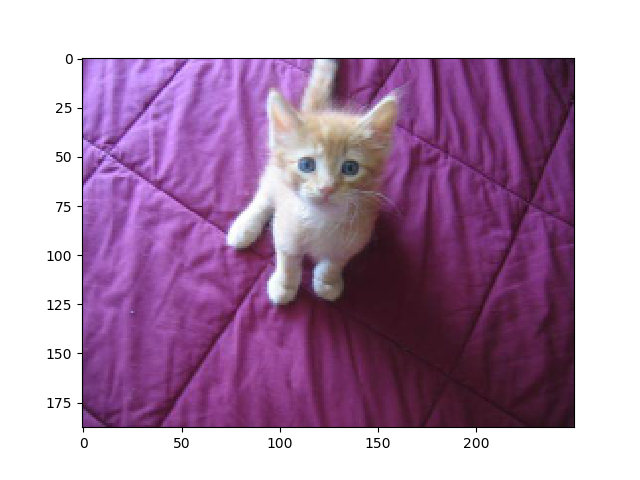

```python
plt.imshow(train[20])
# Display of image should be done before flattening
```

# Neural Network model Cat or Dog

Logistic regression did not work well on the "flower dataset". You are going to train a Neural Network with a single hidden layer.

**Mathematically**:

For one example $x^{(i)}$: $$z^{[1] (i)} = W^{[1]} x^{(i)} + b^{[1]}\tag{1}$$ $$a^{[1] (i)} = \tanh(z^{[1] (i)})\tag{2}$$ $$z^{[2] (i)} = W^{[2]} a^{[1] (i)} + b^{[2]}\tag{3}$$ $$\hat{y}^{(i)} = a^{[2] (i)} = \sigma(z^{ [2] (i)})\tag{4}$$ $$y^{(i)}_{prediction} = \begin{cases} 1 & \mbox{if } a^{[2](i)} > 0.5 \\ 0 & \mbox{otherwise } \end{cases}\tag{5}$$

Given the predictions on all the examples, you can also compute the cost $J$ as follows: $$J = - \frac{1}{m} \sum\limits_{i = 0}^{m} \large\left(\small y^{(i)}\log\left(a^{[2] (i)}\right) + (1-y^{(i)})\log\left(1- a^{[2] (i)}\right) \large \right) \small \tag{6}$$

**Reminder**: The general methodology to build a Neural Network is to:

```
1. Define the neural network structure ( # of input units,  # of hidden units, etc).
2. Initialize the model's parameters
3. Loop:
    - Implement forward propagation
    - Compute loss
    - Implement backward propagation to get the gradients
    - Update parameters (gradient descent)
```

You often build helper functions to compute steps 1-3 and then merge them into one function we call `nn_model()`. Once you've built `nn_model()` and learnt the right parameters, you can make predictions on new data.

### Defining Neural network Structure

**Define Three Variables :**

```
- n_x: The size of the input layer
- n_h: The size of the hidden layer
- n_y: The size of the ouput layer
```

**Hint**: Use X and Y to find n_x and n_y and then hard code the layer size

```python
import numpy as np
import pandas as pd
import matplotlib.pyplot as plt


X = np.array(np.load('input_data.npy'))

Y = np.array(np.load('label.npy'))

Train = pd.DataFrame(X).T.iloc[:,:420]

Test = pd.DataFrame(X).T.iloc[:,420:]

y_Train = pd.DataFrame(Y)[:420]

y_Test = pd.DataFrame(Y)[420:]

y_Test = y_Test.T
y_Train = y_Train.T
```

### Helper functions

```python
def sigmoid(z):
    """Compute Sigmoid of z
    Arguments z => a scaler quantity
    Return s ....... Singmoid(z)"""
    s = 1/(1+np.exp(-z)) # This equation describes the definition of the sigmoid function
    return s
```

```python
def Logcost(A, y_Train):
    m = y_Train.shape[1]
    logs = np.multiply(y_Train, np.log(A)) + np.multiply((1 - y_Train), np.log(1-A))
    cost = -(1/m)*np.sum(logs, axis = 1)
    return cost
```

```python
def layer_sizes(X, Y, n):
    """
    Arguments:
    X -- input dataset of shape (input size, number of examples)
    Y -- labels of shape (output size, number of examples)

    Returns:
    n_x -- the size of the input layer
    n_h -- the size of the hidden layer
    n_y -- the size of the output layer
    """

    n_x = X.shape[0] # size of input layer
    n_h = n
    n_y = Y.shape[0] # size of output layer

    return (n_x, n_h, n_y)
```

```python
n_x, n_h, n_y = layer_sizes(Train, y_Train, 4)
print("The size of the input layer is: n_x = " + str(n_x))
print("The size of the hidden layer is: n_h = " + str(n_h))
print("The size of the output layer is: n_y = " + str(n_y))
```

```
The size of the input layer is: n_x = 46875
The size of the hidden layer is: n_h = 4
The size of the output layer is: n_y = 1
```

### Initialize the model's parameters

- Make sure your parameters' sizes are right.
- You will initialize the weights matrices with random values.
  - Use: `np.random.randn(a,b) * 0.01` to randomly initialize a matrix of shape (a,b).
- You will initialize the bias vectors as zeros.
  - Use: `np.zeros((a,b))` or `b = 0` to initialize b which will become a matrix of shape (a,b) during broadcasting.

```python
def initialize_parameters(n_x, n_h, n_y):
    """
    Argument:
    n_x -- size of the input layer
    n_h -- size of the hidden layer
    n_y -- size of the output layer

    Returns:
    params -- python dictionary containing your parameters:
                    W1 -- weight matrix of shape (n_h, n_x)
                    b1 -- bias vector of shape (n_h, 1)
                    W2 -- weight matrix of shape (n_y, n_h)
                    b2 -- bias vector of shape (n_y, 1)
    """

    np.random.seed(2) # we set up a seed so that your output matches ours although the initialization is random.


    W1 = np.random.randn(n_h,n_x)*0.01
    b1 = np.zeros((n_h,1))
    W2 = np.random.randn(n_y,n_h)*0.01
    b2 = np.zeros((n_y,1))


    assert (W1.shape == (n_h, n_x))
    assert (b1.shape == (n_h, 1))
    assert (W2.shape == (n_y, n_h))
    assert (b2.shape == (n_y, 1))

    parameters = {"W1": W1,
                  "b1": b1,
                  "W2": W2,
                  "b2": b2}

    return parameters
```

```python
parameters = initialize_parameters(n_x, n_h, n_y)
print("W1 = " + str(parameters["W1"]))
print("b1 = " + str(parameters["b1"]))
print("W2 = " + str(parameters["W2"]))
print("b2 = " + str(parameters["b2"]), '\n'*2)

parameters = initialize_parameters(n_x, n_h, n_y)
print("W1 = " + str(parameters["W1"].shape))
print("b1 = " + str(parameters["b1"].shape))
print("W2 = " + str(parameters["W2"].shape))
print("b2 = " + str(parameters["b2"].shape))
```

```
W1 = [[-0.00416758 -0.00056267 -0.02136196 ..., -0.00989743 -0.00656098
   0.00560609]
 [-0.00781498 -0.00282917  0.00115725 ..., -0.00162159  0.00647496
  -0.00277555]
 [ 0.00624816  0.01333095  0.00422484 ..., -0.00162666  0.00039406
   0.00049182]
 [-0.01597993 -0.01324958 -0.00762092 ..., -0.00316868 -0.00421742
  -0.01316135]]
b1 = [[ 0.]
 [ 0.]
 [ 0.]
 [ 0.]]
W2 = [[-0.00293307  0.00426807 -0.00034052 -0.00535128]]
b2 = [[ 0.]]


W1 = (4, 46875)
b1 = (4, 1)
W2 = (1, 4)
b2 = (1, 1)
```

```python
def forward_propagation(X, parameters):
    """
    Argument:
    X -- input data of size (n_x, m)
    parameters -- python dictionary containing your parameters (output of initialization function)

    Returns:
    A2 -- The sigmoid output of the second activation
    cache -- a dictionary containing "Z1", "A1", "Z2" and "A2"
    """
    # Retrieve each parameter from the dictionary "parameters"

    W1 = parameters['W1']
    b1 = parameters['b1']
    W2 = parameters['W2']
    b2 = parameters['b2']


    # Implement Forward Propagation to calculate A2 (probabilities)

    Z1 = np.dot(W1,X) + b1
    A1 = np.tanh(Z1)
    Z2 = np.dot(W2,A1) + b2
    A2 = sigmoid(Z2)


    assert(A2.shape == (1, X.shape[1]))

    cache = {"Z1": Z1,
             "A1": A1,
             "Z2": Z2,
             "A2": A2}

    return A2, cache
```

```python
A2, cache = forward_propagation(Train, parameters)
```

```python
def compute_cost(A2, Y, parameters):
    """
    Computes the cross-entropy cost given in equation (13)

    Arguments:
    A2 -- The sigmoid output of the second activation, of shape (1, number of examples)
    Y -- "true" labels vector of shape (1, number of examples)
    parameters -- python dictionary containing your parameters W1, b1, W2 and b2

    Returns:
    cost -- cross-entropy cost given equation (13)
    """

    m = Y.shape[1] # number of example

    # Compute the cross-entropy cost

    logprobs = np.multiply(np.log(A2), Y) + np.multiply((1 - Y), np.log(1 - A2))
    cost = -(1/m)*np.sum(logprobs, axis=1)


    cost = np.squeeze(cost)     # makes sure cost is the dimension we expect.
                                # E.g., turns [[17]] into 17
    #assert(isinstance(cost, float))

    return cost

print("cost = " + str(compute_cost(A2, Train, parameters)))
```

```
cost = 0        0.693467
1        0.693318
2        0.693075
3        0.693426
4        0.693265
5        0.693011
6        0.693413
7        0.693252
8        0.692987
9        0.693406
10       0.693246
11       0.692982
12       0.693468
13       0.693310
14       0.693049
```

[output cut: 47 more lines]

```python
def back_propagation(parameters, cache, X, Y):
    """
    Implement the backward propagation using the instructions above.

    Arguments:
    parameters -- python dictionary containing our parameters
    cache -- a dictionary containing "Z1", "A1", "Z2" and "A2".
    X -- input data of shape (2, number of examples)
    Y -- "true" labels vector of shape (1, number of examples)

    Returns:
    grads -- python dictionary containing your gradients with respect to different parameters
    """
    m = X.shape[1]

    # First, retrieve W1 and W2 from the dictionary "parameters".
    ### START CODE HERE ### (≈ 2 lines of code)
    W1 = parameters['W1']
    W2 = parameters['W2']
    ### END CODE HERE ###

    # Retrieve also A1 and A2 from dictionary "cache".
    ### START CODE HERE ### (≈ 2 lines of code)
    A1 = cache['A1']
    A2 = cache['A2']
    ### END CODE HERE ###

    # Backward propagation: calculate dW1, db1, dW2, db2.
    ### START CODE HERE ### (≈ 6 lines of code, corresponding to 6 equations on slide above)
    #dZ2 = A2 - Y
    #dW2 = (1/m)*np.dot(dZ2,A1.T)
    #db2 = (1/m)*np.sum(dZ2, axis=1)
    #dZ1 = np.multiply(np.dot(W2.T, dZ2), 1 - np.power(A1, 2))
    #dW1 = (1 / m) * np.dot(dZ1, X.T)
    #db1 = (1 / m) * np.sum(dZ1, axis=1)
    ### END CODE HERE ###

    dZ2 = A2 - Y
    dW2 = (1/m)*np.dot(dZ2, A1.T)
    db2 = np.array([(1/m)*np.sum(dZ2, axis = 1)])
    dZ1 = np.multiply(np.dot(W2.T, dZ2), (1 - np.power(A1, 2)))
    dW1 = (1/m)*np.dot(dZ1, X.T)
    db1 = np.array([(1/m)*np.sum(dZ1, axis =1)]).T

    grads = {"dW1": dW1,
             "db1": db1,
             "dW2": dW2,
             "db2": db2}

    return grads
```

```python
grads = back_propagation(parameters, cache, Train, y_Train)
```

```python
def update_parameters(parameters, grads, learning_rate=0.0002):
    """
    Updates parameters using the gradient descent update rule given above

    Arguments:
    parameters -- python dictionary containing your parameters
    grads -- python dictionary containing your gradients

    Returns:
    parameters -- python dictionary containing your updated parameters
    """
    # Retrieve each parameter from the dictionary "parameters"
    ### START CODE HERE ### (≈ 4 lines of code)
    W1 = parameters['W1']
    b1 = parameters['b1']
    W2 = parameters['W2']
    b2 = parameters['b2']
    ### END CODE HERE ###

    # Retrieve each gradient from the dictionary "grads"
    ### START CODE HERE ### (≈ 4 lines of code)
    dW1 = grads['dW1']
    db1 = grads['db1']
    dW2 = grads['dW2']
    db2 = grads['db2']
    ## END CODE HERE ###

    # Update rule for each parameter
    ### START CODE HERE ### (≈ 4 lines of code)
    #W1 = W1 - learning_rate * dW1
    #b1 = np.array(b1 - learning_rate * db1)
    #W2 = W2 - learning_rate * dW2
    #b2 = np.array(np.squeeze(b2) - learning_rate * db2)
    ### END CODE HERE ###

    W1 = W1 - np.multiply(learning_rate, dW1)
    b1 = b1 - np.multiply(learning_rate, db1)
    W2 = W2 - np.multiply(learning_rate, dW2)
    b2 = np.squeeze(b2) - np.multiply(learning_rate, db2)

    parameters = {"W1": W1,
                  "b1": b1,
                  "W2": W2,
                  "b2": b2}

    return parameters
```

```python
parameters = update_parameters(parameters, grads, 1.2)

print("W1 = " + str(parameters["W1"]))
print("b1 = " + str(parameters["b1"]))
print("W2 = " + str(parameters["W2"]))
print("b2 = " + str(parameters["b2"]))
```

```
W1 = [[-0.00415664 -0.00052383 -0.0213332  ..., -0.00990715 -0.00655722
   0.00558048]
 [-0.00782459 -0.0028444   0.00114436 ..., -0.00161816  0.00647705
  -0.00276538]
 [ 0.00624691  0.0133327   0.00422607 ..., -0.00163072  0.00039141
   0.00048654]
 [-0.0159459  -0.01317748 -0.00755939 ..., -0.00320717 -0.00423285
  -0.01322603]]
b1 = [[  1.75946558e-05]
 [ -1.21349384e-05]
 [ -3.20136306e-06]
 [  2.21936831e-05]]
W2 = [[  8.06955119e-05   7.75708831e-04  -7.18150720e-03   1.04196519e-02]]
b2 = [[ 0.00207141]]
```

```python
def model(X, Y, n_h,learning_rate, num_iterations=10000, print_cost=False):
    """
    Arguments:
    X -- dataset of shape (2, number of examples)
    Y -- labels of shape (1, number of examples)
    n_h -- size of the hidden layer
    num_iterations -- Number of iterations in gradient descent loop
    print_cost -- if True, print the cost every 1000 iterations

    Returns:
    parameters -- parameters learnt by the model. They can then be used to predict.
    """

    np.random.seed(3)
    n_x = layer_sizes(X, Y,n_h)[0]
    n_y = layer_sizes(X, Y,n_h)[2]

    # Initialize parameters, then retrieve W1, b1, W2, b2. Inputs: "n_x, n_h, n_y". Outputs = "W1, b1, W2, b2, parameters".
    ### START CODE HERE ### (≈ 5 lines of code)
    parameters = initialize_parameters(n_x, n_h, n_y)
    W1 = parameters['W1']
    b1 = parameters['b1']
    W2 = parameters['W2']
    b2 = parameters['b2']
    ### END CODE HERE ###

    # Loop (gradient descent)

    costs = []

    for i in range(0, num_iterations):

        ### START CODE HERE ### (≈ 4 lines of code)
        # Forward propagation. Inputs: "X, parameters". Outputs: "A2, cache".
        A2, cache = forward_propagation(X, parameters)

        # Cost function. Inputs: "A2, Y, parameters". Outputs: "cost".
        cost = compute_cost(A2, Y, parameters)

        # Backpropagation. Inputs: "parameters, cache, X, Y". Outputs: "grads".
        grads = back_propagation(parameters, cache, X, Y)

        # Gradient descent parameter update. Inputs: "parameters, grads". Outputs: "parameters".
        parameters = update_parameters(parameters, grads, learning_rate)

        ### END CODE HERE ###

        # Print the cost every 1000 iterations
        costs.append(cost)
        if print_cost and i % 1000 == 0:
            print ("Cost after iteration %i: %f" % (i, cost))
            continue
    plt.figure(figsize=(8,6))
    plt.plot(costs)
    plt.show()
    return parameters
```

```
Cost after iteration 0: 0.692982
Cost after iteration 1000: 0.489590
Cost after iteration 2000: 0.204002
Cost after iteration 3000: 0.077969
Cost after iteration 4000: 0.045654
Cost after iteration 5000: 0.032126
Cost after iteration 6000: 0.024902
Cost after iteration 7000: 0.018855
Cost after iteration 8000: 0.015752
Cost after iteration 9000: 0.013114
```

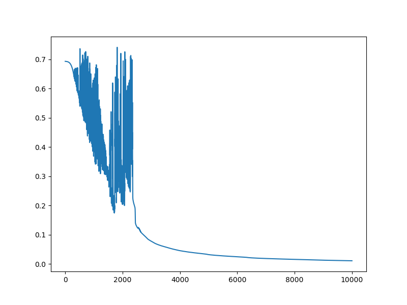

```
W1 = [[-0.00204093  0.00980818 -0.01206448 ..., -0.01053662 -0.00340922
   0.00348081]
 [-0.00561994  0.00733017  0.00761332 ...,  0.00316864  0.01365867
  -0.00229499]
 [ 0.00593214  0.02463456  0.01344462 ..., -0.00027336  0.00254937
  -0.00586695]
 ...,
 [-0.01472755 -0.01610891 -0.00578569 ...,  0.00190616  0.00896716
  -0.00481281]
 [ 0.02246021 -0.0222344   0.00344565 ..., -0.0184248  -0.0029362
  -0.00917233]
 [-0.02206542  0.00075921  0.00067631 ..., -0.00501881  0.01493966
   0.00895577]]
b1 = [[ 0.00025297]
 [-0.01178001]
 [-0.00393836]
 [ 0.01068371]
 [-0.00819362]
 [-0.00279742]
 [ 0.01525701]
 [-0.00128364]]
W2 = [[-1.5265917  -1.15023815 -0.77919686  1.58306928 -1.04359962 -0.91773228
   1.65433163 -1.38888413]]
b2 = [[ 0.06535308]]
```

```python
parameters = model(Train, y_Train,n_h=8, learning_rate=0.01,num_iterations=10000, print_cost=True)
print("W1 = " + str(parameters["W1"]))
print("b1 = " + str(parameters["b1"]))
print("W2 = " + str(parameters["W2"]))
print("b2 = " + str(parameters["b2"]))
```

```python
def predict(parameters, test):
    A2, cache = forward_propagation(test, parameters)
    prediction = np.round(A2, decimals=0)
    return prediction
```

```python
predictions = predict(parameters, Train)

print ('Dev Set Accuracy: %d' % float((np.dot(y_Train,predictions.T) + np.dot(1-y_Train,1-predictions.T))/float(y_Train.size)*100) + '%')
```

```
Dev Set Accuracy: 99%
```

```python
predictions = predict(parameters, Test)

print ('Test set Accuracy: %d' % float((np.dot(y_Test,predictions.T) + np.dot(1-y_Test,1-predictions.T))/float(y_Test.size)*100) + '%')
```

```
Test set Accuracy: 58%
```